# ggplot2 学术绘图案例

# 21. 受力分析图

原文链接：https://zhuanlan.zhihu.com/p/713933641

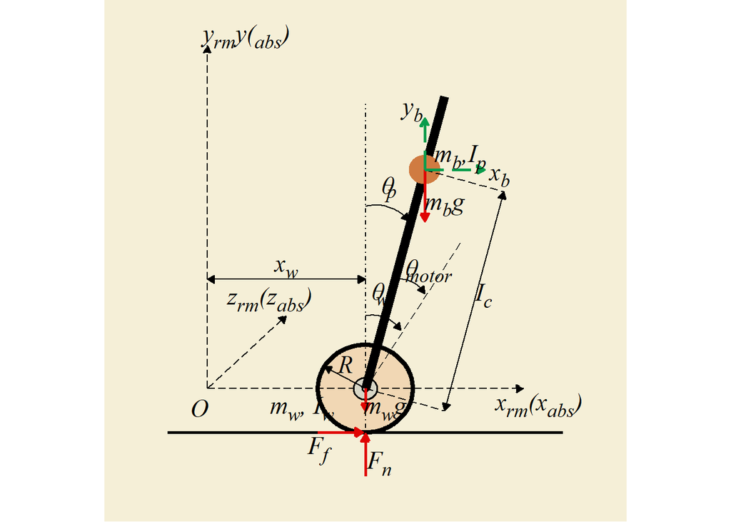

```r
# 加载包
library(ggplot2)
library(ggforce)

# 绘图
ggplot() +
  geom_circle(aes(x0=0,y0=0,r=6),size=1.5,fill="#F1D7B4") +             #大圆
  geom_segment(aes(x=0,y=-6,xend=0,yend=39),linetype="dotdash") +       #圆垂直虚线
  geom_segment(aes(x=-20,y=0,xend=20,yend=0),
               arrow = arrow(length = unit(2,"mm"),type = "closed"),linetype="longdash") + #x轴
  geom_segment(aes(x=-20,y=0,xend=-20,yend=47),
               arrow = arrow(length = unit(2,"mm"),type = "closed"),linetype="longdash") + #y轴
  geom_segment(aes(x=-20,y=0,xend=-10,yend=10),
               arrow = arrow(length = unit(2,"mm"),type = "closed"),linetype="longdash") + #坐标轴短斜线
  geom_circle(aes(x0=0,y0=0,r=1.5),size=.7,fill="#D8D6C6") +            #小圆
  geom_circle(aes(x0=0,y0=0,r=.4),size=.7,fill="#D8D6C6") +             #小圆
  geom_segment(aes(x=0,y=0,yend=3,xend=-3*sqrt(3)),
               arrow = arrow(length = unit(2,"mm"),type = "closed")) +  #大圆半径指示线
  geom_segment(aes(x=0,y=0,xend=10,yend=40),size=3) +                   #从圆延出的粗实线
  geom_circle(aes(x0=7.5,y0=30,r=2),fill="#D07B41",color=NA) +          #线上的实心圆
  geom_segment(aes(x=-20,y=15,xend=0,yend=15),
               arrow = arrow(ends = "both",type = "closed",length = unit(2,"mm"))) + #坐标轴与圆垂线的指示线
  geom_segment(aes(x=0,y=0,xend=12,yend=20),linetype="longdash") +      #圆右上斜线
  geom_segment(aes(x=0,y=0,xend=10,yend=-3),linetype="longdash") +      #圆右下斜线
  geom_segment(aes(x=7.5,y=30,xend=17.5,yend=27),linetype="longdash") + # 实心圆虚线
  geom_segment(aes(x=10,y=-3,xend=17.5,yend=27),
               arrow = arrow(ends = "both",type = "closed",length = unit(2,"mm"))) + #两圆斜线的连线
  geom_segment(aes(x=7.5,y=30,xend=7.5,yend=23),
               arrow = arrow(length = unit(2,"mm"),type = "closed"),color="#E00403",size=1) + #小实心圆受力线
  geom_segment(aes(x=7.5,y=30,xend=15,yend=30),                         #小实心圆受力线
               arrow = arrow(length = unit(2,"mm"),type = "closed"),size=1,
               color="#089D4C",linetype="longdash") +
  geom_segment(aes(x=7.5,y=30,xend=7.5,yend=37),                        #小实心圆受力线
               arrow = arrow(length = unit(2,"mm"),type = "closed"),size=1,
               color="#089D4C",linetype="longdash") +
  geom_segment(aes(x=0,y=0,xend=0,yend=-3),
               arrow = arrow(length = unit(2,"mm"),type = "closed"),color="#E00403",size=1) +  #中心圆重力线
  geom_segment(aes(x=-25,y=-6,xend=25,yend=-6),size=1) +                #大圆下切线
  geom_segment(aes(x=0,y=-12,xend=0,yend=-6.2),
               arrow = arrow(length = unit(2,"mm"),type = "closed"),color="#E00403",size=1) +  #大圆受力线
  geom_segment(aes(x=-6,y=-6,xend=-.4,yend=-6),
               arrow = arrow(length = unit(2,"mm"),type = "closed"),color="#E00403",size=1) +  #大圆受力线
  geom_curve(aes(x=0,y=10,xend=4.5,yend=8),
             arrow = arrow(length = unit(2,"mm"),type = "closed"),curvature = -.3) +           #角度指示线
  geom_curve(aes(x=0,y=25,xend=5.5,yend=23),
             arrow = arrow(length = unit(2,"mm"),type = "closed"),curvature = -.3) +           #角度指示线
  geom_curve(aes(x=4,y=15,xend=7.5,yend=13),
             arrow = arrow(length = unit(2,"mm"),type = "closed"),curvature = -.3) +           #角度指示线
  # 添加文本注释
  ggtext::geom_richtext(data=data.frame(
    x=c(-21,-15,-10,-12,-2.5,-8,2.5,-6,1.8,22,2.8, 1.55, 5.85,3.3,2.1,8,10,6,17,12,15),
    y=c(-3,48,16.5,12,3,-3,-3,-8.5,-10.5,-2.5,27.5,13,16.2,27.5,12.8,16,25,38,29,31.5,12.5),
    label=c("O","y<sub>rm</sub>y(<sub>abs</sub>)", "x<sub>w</sub>",
            "z<sub>rm</sub>(z<sub>abs</sub>)", "R", "m<sub>w</sub>, I<sub>w</sub>",
            "m<sub>w</sub>g", "F<sub>f</sub>", "F<sub>n</sub>",
            "x<sub>rm</sub>(x<sub>abs</sub>)", "θ","θ","θ", "<sub>p</sub>", "<sub>w</sub>",
            "<sub>motor</sub>", "m<sub>b</sub>g", "y<sub>b</sub>",
            "x<sub>b</sub>","m<sub>b</sub>,I<sub>p</sub>","I<sub>c</sub>")),
    aes(x,y,label=label),fontface = "italic",size=6,family="serif",fill=NA,label.color=NA) +
  # 美化
  xlim(c(-30,30)) +
  ylim(c(-15,50)) +
  theme_void() +
  theme(aspect.ratio = 1, plot.background = element_rect(fill="#F5EFD7"))
```

# 22. 小米原研哉logo

小米原研哉logo，公式$|x|^n+|y|^n=1$，其中$n=3$

[figure not shown]

```r
# 加载包
library(ggplot2)

# 定义函数，用于绘制广义圆形（或超圆形），它基于数学上的Lp范数圆（Lp-norm circle），其中n控制形状的圆润程度
circ <- function(n=1){
  acc <- 1000
  x <- seq(-1,1, length.out=acc)
  y <- (1 - abs(x)^n)^(1/n)
  p <- ggplot()+
    geom_line(aes(x,y,group=1), linewidth=1,color="#FF7E00")+
    geom_line(aes(x,-y,group=1), linewidth=1,color="#FF7E00")+
    geom_ribbon(aes(x=x,ymin=-y,ymax=y),fill="#FF7E00")+
    scale_x_continuous(expand=c(0.6,0,0.6,0))+
    scale_y_continuous(expand=c(0.6,0,0.6,0))+
    theme_void()+
    theme(aspect.ratio = 1)
  return(p)
}

# 绘图
circ(3)
```

# 23. 固定长宽比

注意如下两个固定长宽比的关系：

- coord_fixed(ratio=1)或coord_equal()：让xy的尺度单位相同，即x和y的单位长度等长，此时图不一定是正方形
- theme(aspect.ratio=1)：让绘图区域（不包括图例标题等）显示结果长宽相同，此时图一定是正方形，但是x和y的尺度不一样

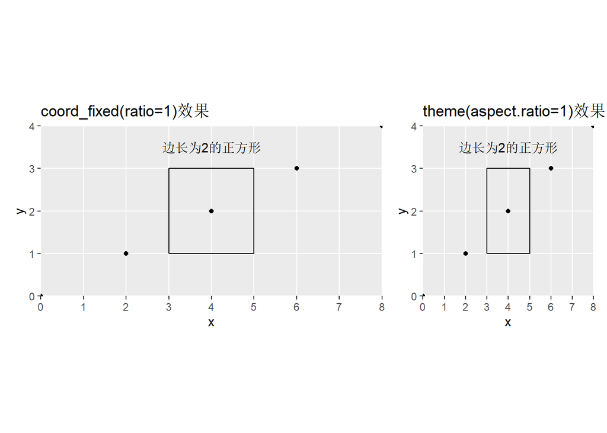

```r
# 加载包
library(ggplot2)
library(patchwork)

# 绘图
p1 <- ggplot()+
  geom_point(aes((0:4)*2,0:4))+
  geom_path(aes(x=c(3,5,5,3,3), y=c(1,1,3,3,1)))+
  geom_text(aes(4,3.5), label="边长为2的正方形")+
  scale_x_continuous(breaks=0:8, expand=c(0,0))+
  scale_y_continuous(expand=c(0,0))+
  labs(x="x", y="y", title="coord_fixed(ratio=1)效果")+
  coord_fixed(ratio=1)+
  theme(panel.grid.minor = element_blank())
p2 <- ggplot()+
  geom_point(aes((0:4)*2,0:4))+
  geom_path(aes(x=c(3,5,5,3,3), y=c(1,1,3,3,1)))+
  geom_text(aes(4,3.5), label="边长为2的正方形")+
  scale_x_continuous(breaks=0:8, expand=c(0,0))+
  scale_y_continuous(expand=c(0,0))+
  labs(x="x", y="y", title="theme(aspect.ratio=1)效果")+
  theme(aspect.ratio=1)+
  theme(panel.grid.minor = element_blank())
p1+p2
```

# 24. ggplot2数学函数

ggplot2中geom_function的几种使用方法

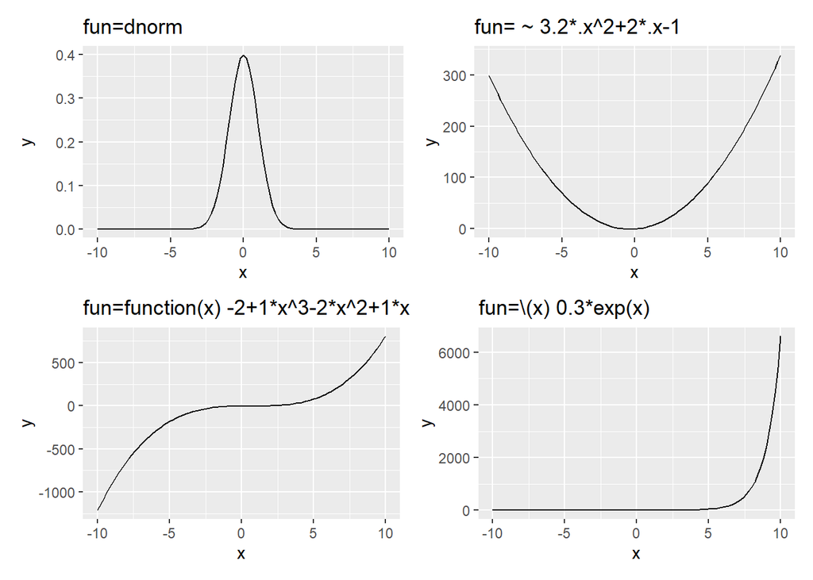

```r
# 加载包
library(ggplot2)
library(patchwork)

# 绘图
p1 <- ggplot()+
  geom_function(fun=dnorm)+
  scale_x_continuous(limits = c(-10,10))+
  ggtitle("fun=dnorm")

p2 <- ggplot()+
  geom_function(fun= ~ 3.2*.x^2+2*.x-1)+
  scale_x_continuous(limits = c(-10,10))+
  ggtitle("fun= ~ 3.2*.x^2+2*.x-1")

p3 <- ggplot()+
  geom_function(fun=function(x) -2+1*x^3-2*x^2+1*x)+
  scale_x_continuous(limits = c(-10,10))+
  ggtitle("fun=function(x) -2+1*x^3-2*x^2+1*x")

p4 <- ggplot()+
  geom_function(fun=\(x) 0.3*exp(x))+
  scale_x_continuous(limits = c(-10,10))+
  ggtitle("fun=\\(x) 0.3*exp(x)")

(p1+p2)/(p3+p4)
```

# 25. 基尼系数与洛伦兹曲线

注意：

- 洛伦兹曲线，表示人口累计百分比与收入累计百分比之间的关系
- 若洛伦兹曲线是对角线，表示没有收入差距，而下凸程度越大，则表示收入差距大
- 基尼系数计算，公式法：$Gini=\frac{\sum_{i=1}^n \sum_{j=1}^n |x_i - x_j|}{2n^2 \cdot \bar{x}}$
- 基尼系数计算，面积法：$Gini=\frac{A}{A+B}$
- 绘制洛伦兹曲线图时，必须先将人口按照收入从低到高排序
- 由于收入事先由低到高排序，因此该曲线不会下凹（因为后面的斜率必然比前面的大）

此外，画图时，如果geom_area或者geom_ribbon填充图，需要画边缘线，则应该先画填充图，后画线，否则会被覆盖掉。

还有一个要注意的问题，ggplot2画图时，如果主函数ggplot()中定义了数据（多行data）和映射aes，则图层若有单个映射并没有用data（如直接`aes(x=1,y=1)`），则会报警告：“All aesthetics have length 1, but the data has 23 rows.”，此时建议用`annotate`代替`geom`图层（如下图中的`annotate`用法），或者额外定义一个dataframe储存映射数据。

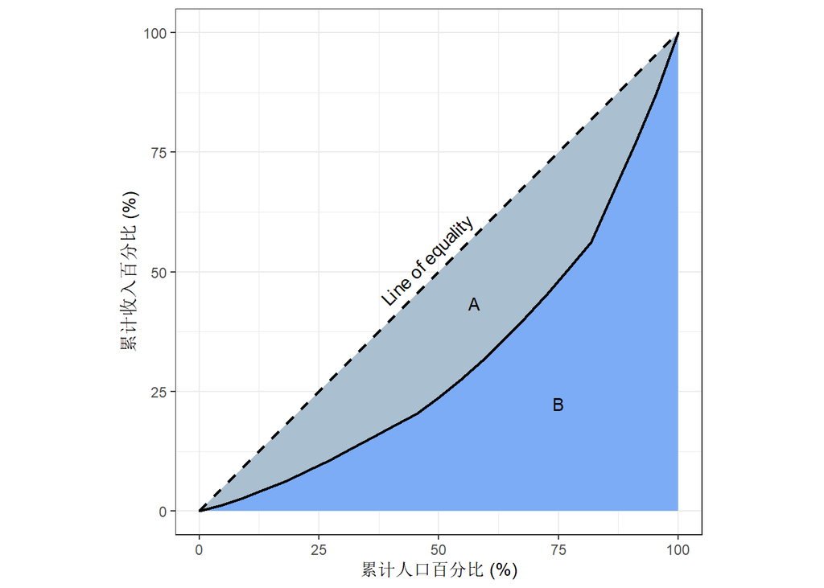

```r
# 加载包
library(ggplot2)
library(data.table)
library(magrittr)

# 基尼系数计算：公式法
gini_index = function(x) {
  # 根据收入向量计算基尼系数
  n = length(x)
  d = outer(x, x, FUN = \(a, b) abs(a - b)) #表示匿名函数，outer结果是一个矩阵
  sum(d) / (2 * n^2 * mean(x))
}

# 基尼系数计算：面积法
gini_index2 = function(income, pop) {
  # 根据收入向量和人口向量计算基尼系数
  # income为各组收入或收入占比
  # pop为各组人数或人数占比
  trapz = function(x, y) {
    # 梯形法近似计算数值积分
    S = 0
    for(i in 2:length(x)) S = S + (x[i] - x[i-1]) * (y[i-1] + y[i]) / 2
    S
  }
  x = c(0, cumsum(pop) / sum(pop))
  y = c(0, cumsum(income) / sum(income))
  (0.5 - trapz(x, y)) / 0.5
}

# 示例数据
dat <- data.table(income = c(1.1,1.5,1.7,1.7,2,2.1,2.2,2.3,2.3,2.3,3.1,3.5,3.8,4.2,
                             4.3,4.7,5,5.1,9.5,9.7,10,12), pop = 1)

# 基尼系数
# gini_index(dat$income)           # 0.3702541
# gini_index2(dat$income, df$pop)  # 0.3702541

# 画图（注意此处数据开头，添加了0数据，不能用于计算基尼系数）
dat_plot <- dat %>%
  setorder(income) %>%
  .[, frac_inc:=cumsum(pop)/sum(pop)*100] %>%
  .[, frac_pop:=cumsum(income)/sum(income)*100] %>%
  rbind(data.table(income=0, pop=1, frac_inc=0, frac_pop=0),.)

# 洛伦兹曲线
ggplot(dat_plot) +
  geom_ribbon(aes(x=frac_inc, ymin=frac_inc, ymax=frac_pop), fill="#AABFCF")+
  geom_area(aes(x=frac_inc, y=frac_pop), fill="#7DACF7")+
  geom_line(aes(frac_inc, frac_pop), color="black", linewidth=0.8, lineend="round")+
  geom_line(aes(frac_inc, frac_inc), color="black", linewidth=0.8, linetype=2)+
  annotate("text", x=50, y=50, label="Line of equality", angle=45, vjust=-0.8)+
  annotate("text", x=57.5, y=43.5, label="A")+
  annotate("text", x=75, y=22.5, label="B")+
  coord_equal() +
  labs(x = "累计人口百分比 (%)", y = "累计收入百分比 (%)")+
  theme_bw()
```

# 26. 因子差异比较

代码修改自Stack Overflow： https://stackoverflow.com/questions/79593647/attaching-labels-estimating-proportion-of-posterior-density-within-an-interval-i

这个代码，以iris数据的花萼宽度为响应变量，以花类型*萼片长度类别为解释变量，使用brms包用贝叶斯回归建模，分析了两种类别下，与基准模型（Species = setosa 且 SepalLength_cat = cat1）差异大小，并使用ggplot进行展示。

由于程序计算较为耗时，因此这里只放了代码，以及此前运行的结果图

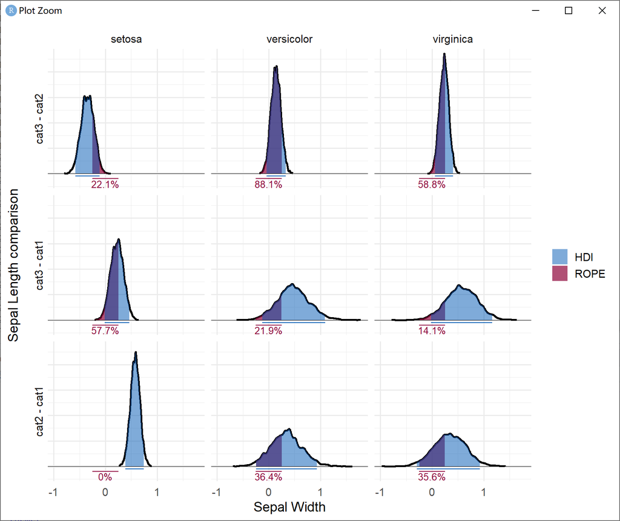

```r
# 加载包
library(tidyverse)
library(brms)
library(modelr)
library(ggdist)
library(tidybayes)
library(marginaleffects)

# 花萼数据分类
# 条件1：长度在[4.3,5)时为"cat1"
# 条件2：长度在[5.1,6.4)时为"cat2"
# 其他情况（包括[5,5.1)和≥6.4）归为"cat3"
irisAlt <- iris %>%
  mutate(SepalLength_cat = factor(case_when(Sepal.Length >= 4.3 & Sepal.Length < 5.0 ~ "cat1",
                                            Sepal.Length >= 5.1 & Sepal.Length < 6.4 ~ "cat2",
                                            TRUE ~ "cat3")))

# 拟合一个贝叶斯线性模型
mod <- brm(formula = Sepal.Width ~ Species*SepalLength_cat, data = irisAlt)

# 对这个模型拟合结果的解释如下：
# > mod
# Family: gaussian
# Links: mu = identity; sigma = identity
# Formula: Sepal.Width ~ Species * SepalLength_cat
# Data: irisAlt (Number of observations: 150)
# Draws: 4 chains, each with iter = 2000; warmup = 1000; thin = 1;
# total post-warmup draws = 4000
#
# Regression Coefficients:
#                                       Estimate Est.Error l-95% CI u-95% CI Rhat Bulk_ESS Tail_ESS
# Intercept                                 3.14      0.07     3.01     3.27 1.00     3075     3194
# Speciesversicolor                        -0.74      0.31    -1.36    -0.17 1.00     1744     2147
# Speciesvirginica                         -0.64      0.31    -1.25    -0.04 1.00     1492     1722
# SepalLength_catcat2                       0.57      0.09     0.39     0.75 1.00     3108     2589
# SepalLength_catcat3                       0.22      0.12    -0.02     0.46 1.00     2862     3170
# Speciesversicolor:SepalLength_catcat2    -0.24      0.32    -0.84     0.40 1.00     1741     2062
# Speciesvirginica:SepalLength_catcat2     -0.23      0.33    -0.88     0.41 1.00     1447     1841
# Speciesversicolor:SepalLength_catcat3     0.25      0.33    -0.41     0.92 1.00     1730     2275
# Speciesvirginica:SepalLength_catcat3      0.35      0.33    -0.30     0.99 1.00     1475     1916
#
# Further Distributional Parameters:
#   Estimate Est.Error l-95% CI u-95% CI Rhat Bulk_ESS Tail_ESS
# sigma     0.30      0.02     0.27     0.34 1.00     3972     2899
#
# Draws were sampled using sampling(NUTS). For each parameter, Bulk_ESS
# and Tail_ESS are effective sample size measures, and Rhat is the potential
# scale reduction factor on split chains (at convergence, Rhat = 1).
#
# 上述拟合结果表示：
# Family: gaussian，假设响应变量服从高斯分布
# Links: mu = identity; sigma = identity，连接函数定义为恒等，即模型直接预测响应变量的均值和标准差。
# Formula，模型解释变量为两个分类因子，响应变量为Sepal.Width是萼片宽度（连续变量）
# Species * SepalLength_cat 表示需要种类与萼片长度分类之间的交互作用项
# thin = 1 表示未进行抽样稀疏处理。
# 回归系数中，
#   Intercept，截距，估计值为3.14，表示在基准水平（Species = setosa 且 SepalLength_cat = cat1）下的平均萼片宽度。
#   Speciesversicolor，估计值为 -0.74，表示在 SepalLength_cat = cat1 时，versicolor 相较于 setosa 的平均萼片宽度减少 0.74。
#   SepalLength_catcat2，估计值为 0.57，表示在 Species = setosa 时，cat2 相较于 cat1 的平均萼片宽度增加 0.57。
#   Speciesversicolor:SepalLength_catcat2：估计值为 -0.24，表示在 versicolor 与 cat2 组合下，相较于基准水平平均减少 0.24。

# 创建对所有可能因子组合的贝叶斯预测
# 其中，modelr::data_grid生成网格数据，此处是3个因子×三个因子，一共是9行
#       tidybayes;;add_epred_draws从贝叶斯模型mod中提取每个预测点的后验预测分布，re_formula = NA：预测时不包括随机效应，仅固定效应
modPred <- data_grid(data = irisAlt,
                     Species = c("setosa", "versicolor", "virginica"),
                     SepalLength_cat = c("cat1", "cat2", "cat3")) %>%
  add_epred_draws(mod, re_formula = NA, seed = 1234)


# tidybayes::compare_levels，这里对SepalLength_cat的所有水平进行两两比较，计算每对水平之间的差异。
# compare levels
compCat <- modPred %>%
  compare_levels(variable = .epred, by = SepalLength_cat) %>%
  mutate(SepalLength_cat = factor(x = SepalLength_cat, levels = c("cat2 - cat1", "cat3 - cat1", "cat3 - cat2")),
         Species = factor(Species))

# 计算高密度区间
# ggdist::hdi计算高密度区间，注意要放在summarise中
hdi <- compCat %>%
  group_by(Species, SepalLength_cat) %>%
  summarise(as_tibble(hdi(.epred))) %>%
  rename(hdi.lwr=V1, hdi.upr=V2)

# 计算密度
# adj，是密度估计的平滑参数，较小的值会使密度曲线更尖锐，较大的值会使曲线更平滑。
# group_split，将数据按物种和萼片长度分类分组，并将每个分组拆分为一个以tibble为元素的list
# map_df(~{ ... })对每个分组的数据执行以下操作，并将结果合并为一个数据框：
#   首先，使用ggdist::density_bounded对.epred 值进行密度估计，结果中，xy分别是密度函数被评估的点及对应的密度值
#   然后，生成一个tibble，
#     .x是当前迭代的元素，map_df()会对列表中的每个元素（即每个tibble）迭代，.x 就代表当前处理的那个分组数据框。
#     Species取当前.x的Species的第一元素，因为所有元素都一样
adj <- 0.5
dens.hist <- compCat %>%
  group_by(Species, SepalLength_cat) %>%
  group_split() %>%
  map_df(~{
    dens = density_bounded(.x$.epred, adjust=adj)
    tibble(Species=.x$Species[1],
           SepalLength_cat=.x$SepalLength_cat[1],
           x=dens$x,
           .epred=dens$y)
  }) %>%
  left_join(hdi)

# 计算等效区间（ROPE），即认为在该区间内的预测值差异可以被视为“无显著差异”或“可接受的差异”。
rope.rng <- c(-0.25, 0.25)
rope.dens <- dens.hist %>%
  filter(x >= min(rope.rng), x <= max(rope.rng)) %>%
  group_by(Species, SepalLength_cat) %>%
  summarise(rope.dens = sum(mean(diff(x)) * .epred)) %>%
  rbind(data.frame(Species="setosa", SepalLength_cat="cat2 - cat1", rope.dens=0))   #额外补上一行0%的

# 设置颜色
rope.color = hcl(0, 80, 30, alpha=c(1, 0.7))
hdi.color = hcl(240, 100, 30, alpha=c(1,0.5))

# 设置主题样式
theme_set(theme_minimal(base_size=14))

# 画图
dens.hist %>%
  ggplot(aes(x, .epred)) +
  geom_hline(yintercept=0, linewidth=0.1, colour="black") +
  # Overall densities
  geom_line(linewidth=1) +
  # Shade ROPE
  geom_area(data=. %>% filter(x >= min(rope.rng), x <= max(rope.rng)), aes(fill="ROPE")) +
  # Shade HDI
  geom_area(data=. %>% filter(x >= hdi.lwr, x <= hdi.upr), aes(fill="HDI")) +
  # HDI segment
  geom_segment(data=hdi, aes(x=hdi.lwr, xend=hdi.upr, y=-0.1, yend=-0.1, colour="HDI")) +
  # ROPE segment
  geom_line(data=. %>% group_by(Species, SepalLength_cat) %>%  reframe(x=rope.rng, .epred=-0.2), aes(colour="ROPE")) +
  # ROPE density value
  geom_text(data=rope.dens, size=3.5, vjust=0.5, aes(label=paste0(round(rope.dens*100, 1),"%"),
                                                     x = mean(rope.rng), y = -0.4, colour="ROPE")) +
  facet_grid(cols=vars(Species), row=vars(fct_rev(SepalLength_cat)), switch="y") +
  scale_y_continuous(expand=c(0.03, 0.03)) +
  scale_fill_manual(values=c(ROPE=rope.color[2], HDI=hdi.color[2])) +
  scale_colour_manual(values=c(ROPE=rope.color[1], HDI=hdi.color[1])) +
  guides(colour="none") +
  labs(y="Sepal Length comparison", x="Sepal Width", fill=NULL)+
  theme_minimal(base_size=14)+
  theme(
    strip.text.y.left=element_text(angle=90, vjust=0.02),
    axis.text.y=element_blank(),
    axis.ticks.y=element_blank()
  )
```